# Workforce Downsizing and Firm Performance: An Organizational Routine Perspective

Converted from PDF `Brauer-DownsizingFirmPerformance-2014-JMS.pdf` · 23 pages · anchors: page `#pN`, block `#pN-bK`

Page 1

### **Workforce Downsizing and Firm Performance: An Organizational Routine Perspective**

### **Matthias Brauer and Tomi Laamanen**

*University of Luxembourg; University of St. Gallen*

ABSTRACT While there is an extensive body of work on how organizational routines emerge and evolve over time, there is a scarcity of research on what happens when routines are disrupted or disbanded through the elimination of key individuals involved in them. This study is the first to theorize and empirically examine the relationship between the magnitude of workforce downsizing and firm performance applying an organizational routine perspective. Consistent with prior research on organizational routines, we posit that small-scale downsizing leads to efficiency improvements without disrupting the existing routines. While larger routine disruptions occur in both medium- and large-scale downsizing, we further argue and find that large-scale downsizing tends to be more beneficial than medium-scale downsizing. Building on prior research on routines, we reason that in medium-scale downsizing employees try to salvage the impaired, partially functioning routines, while large-scale downsizing requires a more fundamental rethinking and re-creation of routines leading to more positive outcomes. Our study contributes to downsizing research through the application of the organizational routine perspective to explain the financial outcomes of downsizing. In doing so, we depart from the widely held assumption in the downsizing literature that the relationship between the magnitude of downsizing and firm performance is linear. Our study also extends prior research on organizational routines by highlighting the usefulness of conceiving routines as mindful accomplishments where the pressure to engage in path-breaking cognitive effort may lead to better results than path-dependent repairing of routines.

**Keywords:** firm performance, organizational routines, workforce downsizing

#### **INTRODUCTION**

The significance of routines as core building blocks of organizational capabilities is well established in prior research (e.g., Aime et al., 2010; Becker, 2004; Eisenhardt and Martin, 2000; Felin et al., 2012; Salvato, 2009). While there are a number of alternative definitions for the concept of routines, they all tend to share the idea that routines are ‘a

*Address for reprints*: Matthias Brauer, Faculty of Law, Economics and Finance, Université du Luxembourg, Campus Limpertsberg, BRC 1.06e, 162A, avenue de la Faïencerie, L-1511 Luxembourg (matthias.brauer@ uni.lu).

© 2013 John Wiley & Sons Ltd and Society for the Advancement of Management Studies

*Journal of Management Studies* 51:8 December 2014 doi: 10.1111/joms.12074

Page 2

recurrent pattern of collective activity’ (Becker, 2004) and can be described as patterns of behavioural interactions between members of an organization (Cohen and Bacdayan, 1994; Pentland and Rueter, 1994). Routines involve and are performed by multiple actors (Becker et al., 2006; Feldman, 2003; Feldman and Pentland, 2003), making actors and their interactions central to the idea of routines.

While earlier research has extensively analysed how organizational routines emerge and evolve over time (e.g., Becker et al., 2006; Bruderer and Singh, 1996; Tripsas, 2009), there is a scarcity of studies on what happens when routines are disrupted (e.g., Edmondson et al., 2001) or disbanded through the elimination of key individuals involved in them (e.g., Aime et al., 2010). Workforce downsizing which incurs changes in the absolute number of jobs, changes in job occupancy due to redefinitions of positions and responsibilities, and disruptions of organizational relationship networks represents one of the most commonly occurring shocks to organizational routines and their outcomes. Surprisingly, however, extant research has not integrated the organizational routine perspective to the study on the effects of workforce downsizing and firm performance.

In this paper, we suggest that the routine perspective may be a powerful lens to explain the relationship between workforce downsizing and firm performance. We argue and also demonstrate empirically that it can bring new clarity to the seemingly contradictory empirical results on the relationship between workforce downsizing and firm performance. Specifically, we argue that the magnitude of downsizing plays an important role as the likelihood for a major disruption of organizational routines increases with the extent of workforce downsizing. The likelihood for disruptions increases with the extent of workforce downsizing as the amount of work performed by the remaining employees increases greatly and as ‘holes’ in organizational routines are created. The responsiveness of employees to these routine disruptions as well as the rigour of this response, however, is likely to differ based on employees’ perceived urgency and motivation for rethinking and re-creating organizational routines. Thus, even though disruptions increase with the *magnitude* of workforce downsizing, the perceived urgency and motivation for employees to engage in re-conceptualizing routines can also be expected to increase.

Due to this joint effect, we argue that the relationship between the magnitude of workforce downsizing and firm performance is non-linear, with medium-scale downsizing leading to the smallest improvements in firm performance. Small-scale downsizing is argued to lead to more significant performance improvements than medium-scale downsizing since small-scale downsizing eliminates operational inefficiencies without disrupting existing routines. While routine disruptions occur in both medium- and large-scale downsizing, greater performance improvements for large-scale downsizing relative to medium-scale downsizing are argued to result from the fact that organizational members are likely to expend more effort on how to re-conceptualize and re-create organizational routines (Armstrong-Stassen, 1994; Brockner et al., 1997; Zellmer-Bruhn, 2003). In contrast, following medium-scale downsizing, organizational members are cognitively relatively more inert and try to manage with the impaired, only partially functioning routines.

In addition to this predicted non-linear baseline effect, we examine the timing of the workforce downsizing decision. We focus on timing as a process contingency factor because both theory and prior empirical research suggest that the timing of workforce

M. Brauer and T. Laamanen 1312

© 2013 John Wiley & Sons Ltd and Society for the Advancement of Management Studies

Page 3

downsizing influences employees’ ability to respond to organizational disruptions (e.g., Cameron, 1994; Love and Nohria, 2005). Prior conceptual and empirical research on organizational restructuring has shown that restructuring outcomes are contingent on the proactiveness (or reactiveness) of the restructuring decision (Brauer and Wiersema, 2012; Buchholtz et al., 1999; Markides, 1995). Our study contributes to existing research in several ways. First, by adopting an organizational routine perspective, we bring in a new theoretical lens to examine the relationship between workforce downsizing and firm performance. Drawing on prior research on organizational routines, we propose that different magnitudes of downsizing engender different needs for adapting and repairing routines and conclude that the relationship between the magnitude of downsizing and firm performance might in fact be non-linear. In contrast, prior research on downsizing has generally assumed a linear relationship (Datta et al., 2010). The organizational routine perspective further allows us to better link the findings from studies on the individual-level outcomes of downsizing to studies that have analysed organization-level outcomes. This is because individuals are at the heart of organizational routines, which in turn constitute organizational capabilities that influence organizational effectiveness (Felin et al., 2012).

Second, our study contributes to organizational routine literature and the debate on whether routines should be conceptualized as evolutionary behavioural patterns (Ashforth and Fried, 1988) or as effortful accomplishments (Pentland and Rueter, 1994, p. 488) with a strong mindful component (Feldman, 2000; Feldman and Pentland, 2003). Though we do not directly observe the process of routine re-creation, our empirical results suggest that in addition to their path dependent characteristics (Becker, 2004), routines are also cognitive accomplishments that can be re-established at a high performance level even after major punctuated disruptions (Gersick, 1991). If organizational routines were only products of evolutionary patterns, the magnitude of downsizing would have to be linearly negatively associated with subsequent performance. To the contrary, however, our findings suggest that organizations may be able to re-create their routines relatively fast even after large-scale downsizing and with higher performance consequences than after medium-scale downsizing.

In the next section, we briefly review prior literature on workforce downsizing. Adopting an organizational routine perspective, we then put forward our hypotheses on the relationship between workforce downsizing and firm performance. Subsequently, we present our research design and empirical findings and conclude with a discussion.

#### **PRIOR RESEARCH ON WORKFORCE DOWNSIZING**

We define workforce downsizing as the intentional reduction in the number of people of an organization accomplished through managerial actions such as hiring freezes, normal or induced attrition, and layoffs (Cameron, 1994; Cameron et al., 1991; Cascio, 1993; Dewitt, 1998; Freeman, 1999; Freeman and Cameron, 1993; Kozlowski et al., 1993). In a recent review, Datta et al. (2010) identified 36 studies that had examined the relationship between workforce downsizing and organizational performance. Of these, 20 studies had focused on investor reactions to downsizing announcements, 19 studies had

Workforce Downsizing and Firm Performance 1313

© 2013 John Wiley & Sons Ltd and Society for the Advancement of Management Studies

Page 4

examined the impact of downsizing on accounting performance, and 16 studies had analysed the influence of downsizing on organizational efficiency and other outcomes.

While the main conclusion of Datta et al.’s (2010) review regarding investor reactions to downsizing announcements is that the announcements, on average, have a negative effect on stock prices, their findings regarding the effects of downsizing on firm profitability are more ambiguous. There are studies suggesting that workforce reductions lead to performance improvements in the medium term (e.g., Kang and Shivdasani, 1997; Palmon and Sun, 1997; Perry and Shivdasani, 2005), but there are also studies showing that workforce downsizing can have a negative effect on profitability (e.g., Cascio et al., 1997; Datta et al., 2012; DeMeuse et al., 1997; Espahbodi et al., 2000; Guthrie and Datta, 2008; Hallock et al., 2012). In their analysis of the downsizing literature, Datta et al. (2012) conclude that the findings on the effects of downsizing on firm profitability are equivocal and that there may be important moderating effects that have not been accounted for. We argue that some of this inconsistency may also be due to the overreliance on linear models in studies which have incorporated the magnitude of workforce downsizing in their empirical designs.

When analysing the prior research on the performance implications of downsizing, we identified two main streams of research: (1) research investigating differences in the performance of downsizing and non-downsizing firms; and (2) research on the effects of magnitude of downsizing on the performance of the downsizing firm. The findings of the first stream are somewhat inconclusive. While some studies in this stream (Chen et al., 2001; Espahbodi et al., 2000; Kang and Shivdasani, 1997; Palmon and Sun, 1997; Yu and Park, 2006) found that downsizing firms tend to outperform non-downsizing firms in the first couple of years following downsizing,<sup>[1]</sup> other studies found employee downsizing to lead to neither performance improvements nor performance decreases when compared with non-downsizing firms (e.g., DeMeuse et al., 1994; Guthrie and Datta, 2008; Suarez-Gonzalez, 2001). However, given the focus on the performance differences between downsizing and non-downsizing firms, most of the studies did not specifically examine the magnitude of downsizing.

The second stream of research focuses specifically on examining the effects of the magnitude of downsizing on firms’ post-downsizing performance. There is, however, also ambiguity in these results, with some papers reporting insignificant and others positive effects. For example, Bruton et al. (1996) found that the extent of workforce downsizing was unable to explain firms’ post-downsizing return on assets (ROA). Also, Cascio et al. (1997) investigated the impact of changes in employment on firms’ return on assets (ROA). After controlling for industry effects, they found that the effect on ROA was not significantly different from the industry average. In another paper, which examined the impact of downsizing on a broader range of financial outcomes and longer term performance, Cascio (1997) found that the magnitude of downsizing has no effect on the average performance in the three years following the downsizing.

These results were further supported by DeMeuse et al. (2004) who did not find significant performance differences between firms that downsized less than 3 per cent and those firms that laid off more than 3 per cent of their workforce. Other studies have also examined the impact of magnitude of workforce downsizing on alternative organizational outcomes, and found no significant relationship. For instance, Brockner

M. Brauer and T. Laamanen 1314

© 2013 John Wiley & Sons Ltd and Society for the Advancement of Management Studies

Page 5

et al. (1994) found that magnitude of downsizing did not have a perceptible impact on organizational trust and support when survivors perceived high procedural fairness.<sup>[2]</sup>

Finally, Wagar (1998) examined the effect of the magnitude of workforce downsizing on efficiency, operationalized with different efficiency measures, and found no significant relationship.

In contrast to these studies, Wayhan and Werner (2000) examined the 250 largest US corporations that had reduced their workforce by at least 3 per cent during the period 1991–92 and found significant improvements in sales and market capitalization in the four years following downsizing. Similarly, Baumol et al. (2003) found the percentage change in mean employment to be positively associated with subsequent firm profitability.

Finally, the findings by Kang and Shivdasani (1997) suggest that performance effects resulting from workforce downsizing may require time to materialize. They found that the operating performance does not necessarily improve in the first or the second year after downsizing, but they did find evidence of improved operating performance in the third year.

In summary, it seems that while a number of studies on workforce downsizing have not accounted for the magnitude of downsizing, other studies have widely assumed the relationship to be linear. When predicting the relationship between workforce downsizing and firm performance improvements using an organizational routine perspective, however, both a consideration of the magnitude of workforce downsizing and departure from the linearity assumption are needed. We will next discuss in more detail the linkage between the magnitude of workforce downsizing and routine disruption as well as routine re-creation.

#### **RESEARCH ON ORGANIZATIONAL ROUTINE DISRUPTIONS**

In organizational routine literature, opinions differ on the degree of consciousness with which actors carry out organizational routines. One perspective proposes that routines are characterized by automated, habituated, or even mindless behaviours (Ashforth and Fried, 1988). A more recent, increasingly dominant perspective views routines as ‘effortful accomplishments’ (Pentland and Rueter, 1994, p. 488) capable of continuous, endogenous change (Becker, 2004; Feldman, 2000; Lazaric, 2011). Proponents of the second position argue in particular that organizational routines are not only simply followed or reproduced – rather, people have a choice between following or amending an organizational routine (Feldman, 2000; Orlikowski, 2002; Pentland, 1995; Pentland and Rueter, 1994).

Routines are thus not only products of subconscious rule-following but involve deliberate adaptive and creative behaviours by the actors involved in the routine making (Feldman, 2000; Ulrich, 2011). By introducing the distinction between the ostensive and performative aspects of organizational routines, Feldman (2000, 2003) and Feldman and Pentland (2003) made an important contribution in explicitly accounting for the cognitive ‘design’ aspects of routines. The ostensive aspect refers to the cognitive representation of a routine – the way in which certain tasks are intended to be accomplished. In contrast, the performative aspect of a routine refers to the actual performances engaged

Workforce Downsizing and Firm Performance 1315

© 2013 John Wiley & Sons Ltd and Society for the Advancement of Management Studies

Page 6

in by the people carrying out the routine. The actual performances in realizing a routine may differ quite significantly from the intended ostensive aspects of a routine.

Therefore routines are seen to have qualities for both stability and change (Pentland, 1995; Pentland and Rueter, 1994). Routines can change continuously as actors interact with each other and come up with better ways of realizing a given task (Feldman, 2000). The adaptive perspective on organizational routines thus proposes that actors in the organization adapt to the new conditions and often find more efficient operating procedures (Adler et al., 1999; Feldman, 2000; Pentland and Feldman, 2005).

When outcomes fall short of ideals, the performance feedback effect (e.g., Greve, 1998) may motivate continued striving, encouraging organizational actors to seek new ideas and actions leading to an improved outcome. Along similar lines, Zellmer-Bruhn (2003) found that teams experiencing severe disruptions will be more likely to either search for or adopt new routines from external, rather than internal sources. This may increase organizational effectiveness as the greater outside orientation may generate novel ideas or ease organizational rigidities and biases ingrained in internal decision-making processes.

In our theorizing, we build in particular on the cognitive aspects of routine re-creation. While earlier research has found that changes in routines can be driven by changes in the external environment (e.g., Cohen et al., 1996) or discontinuous changes can be driven by combinations of routines or imperfect internal replication (Becker et al., 2006), we focus on the cognitive effort and motivation needed for changing routines in the face of major routine disruption through workforce downsizing.<sup>[3]</sup>

When approaching the change of routines from the perspective of cognitive effort, we argue that there is a major difference in whether routines are simply adapted through local search with lower cognitive effort (e.g., Argote and Greve, 2007; Cyert and March, 1963) or whether a more significant cognitive effort is undertaken to re-create routines through more extensive search processes. Importantly, the two views on the amount of cognitive effort invested result in different predictions regarding the relationship between workforce downsizing and firm performance. Specifically, we theorize that depending on the magnitude of workforce downsizing, organizational members invest different amounts of cognitive effort to repair or re-create the disrupted routines, leading to different performance implications.

#### **Magnitude of Workforce Downsizing and Firm Performance Change**

When firms engage in relatively small-scale workforce downsizing, they eliminate operational inefficiencies but at the same time are able to fully safeguard their resources and to preserve their routines. Employees will thus see little need for adaptation of organizational routines or extensive search and experimentation with better ways of carrying out an organizational routine. For the most part, a positive relationship between small-scale workforce downsizing and change in profitability is thus likely to result from improved operational efficiency. Routines change in an incremental way consistent with the view of routine evolution as a source of continuous endogenous change (Feldman, 2000).

M. Brauer and T. Laamanen 1316

© 2013 John Wiley & Sons Ltd and Society for the Advancement of Management Studies

Page 7

In medium-scale workforce downsizing, most organizational routines can be expected to remain functional. Disruptions, however, are likely to occur at an increasing frequency in different parts of the organization as the organizational routines become stretched to their limits. Essentially, greater negative survivor effects paired with these disruptions following medium-scale downsizing are likely to lead to inferior performance outcomes when compared with small-scale downsizing.

While routine disruptions occur in both medium- and large-scale downsizing, the responsiveness of employees to these routine disruptions, as well as the rigour of this response, are likely to differ based on employees’ perceived urgency and motivation for rethinking and re-creating the affected organizational routines. Both can be expected to increase with the magnitude of downsizing. Though disruptions occur, medium-scale downsizing may not, however, yet force the organization to adapt or repair organizational routines beyond the level necessary to maintain current operations. Instead, there is an inertial tendency in organizations to rely on the past and to ‘make do’ with the routines that have been built over time (Hodgkinson, 2003; Tripsas, 2009).

In contrast, incremental patching or mending of existing routines is no longer viable following large-scale workforce downsizing. Prior routines become so dysfunctional due to the lack of resources that they cannot be salvaged any more and entirely new routines have to be envisioned and developed to fit to the new reality (Lazaric, 2011). Consistent with this notion that the positive effects of large-scale organizational downsizing are driven by the added pressure to cognitively rethink the routines needed in the new reality instead of trying to salvage the impaired prior routines, Zellmer-Bruhn (2003) found that teams experiencing severe disruptions will be more likely to either search for or adopt new routines from external, rather than internal sources which may increase organizational effectiveness as the greater outside orientation may generate novel ideas and/or ease organizational rigidities and biases ingrained in internal decision-making processes. As a consequence of the organization being inert to repair or re-create its routines in medium-scale downsizing, organizational performance is likely to develop less positively when compared with large-scale downsizing which increases employees’ urgency to engage in a complete rethinking of their routines. Based on the above reasoning, we predict a non-linear effect between the magnitude of workforce downsizing and post-downsizing performance:

*Hypothesis 1*: The relationship between the magnitude of workforce downsizing and post-downsizing performance change is non-linear, with the relationship exhibiting a U-shaped pattern.

#### **Moderating Influence of the Timing of Workforce Downsizing**

Building on the organizational routine perspective, we posit in our first hypothesis that the magnitude of workforce downsizing is associated with disparate levels of employees’ cognitive and practical efforts in rethinking and repairing routines. In addition to the magnitude of workforce downsizing, employees’ efforts at routine repair are also likely to be governed by their discretion to do so. The timing of downsizing is therefore a potentially important process contingency.

Workforce Downsizing and Firm Performance 1317

© 2013 John Wiley & Sons Ltd and Society for the Advancement of Management Studies

Page 8

Cameron highlighted in his pioneering work the importance of timing by noting that ‘downsizing may be reactive and defensive, or it may be proactive and anticipatory’ (Cameron, 1994, p. 192). Following Cameron’s insight, we classify firms which downsized without having experienced a decline in market value prior to downsizing as proactive and firms which downsized after having experienced a decline as reactive or defensive (e.g., Love and Nohria, 2005).

An effective reorganization of work processes requires a minimum dedication of time. In the absence of the necessary time to make these adjustments, performance is likely to develop less favourably in the post-downsizing period regardless of the scale of downsizing. Another important aspect of our theoretical argument is that (reactive) downsizing under conditions of declining financial performance increases time pressure. Under time pressure, firms are less likely to be able to conduct an ordered and wellstructured downsizing process (Ginsberg and Baum, 1994).

Deteriorating performance has also been found to be associated with crisis mentality, resistance to change, restricted communication, lack of teamwork, and a rigid response (Cameron et al., 1987a, 1987b; Staw et al., 1981). Furthermore, prior research suggests that time pressure may not only constrain the *willingness* to rethink existing routines but also constrain their *creativity* in doing so, as well as curb employees’ motivation and efforts in planning, enacting, and learning new routines. (e.g., Unsworth and Clegg, 2000).<sup>[4]</sup>

Similarly, Gilson et al. (2004) found that late downsizers were associated with significantly lower employee satisfaction and workplace performance and higher conflict when compared with non-downsizers or early downsizers.

Under conditions of reactive downsizing, heightened perceived time pressure is thus likely to decrease employees’ willingness and ability to engage in routine reconceptualization and re-creation. Consequently, not only will reactive downsizing, on average, be associated with lower post-downsizing performance improvements, but the U-shaped relationship between the magnitude of workforce downsizing and firm performance improvements will be *less* pronounced under these circumstances. This is because the sense of urgency and the motivational effects which may encourage organizational members to rethink routines after large-scale downsizing may be offset by high time pressure.

In contrast, under conditions of proactive downsizing, the availability of time can be expected to positively moderate an organization’s ability to rebuild its routines irrespective of whether it is engaging in small-scale, medium-scale, or large-scale downsizing. When an organization is still performing well, routine disruptions can be expected to be addressed with careful planning. Lack of time pressure gives the organization the latitude to think about adjustments and to search for new solutions, easing the pressure to adapt or rebuild routines. Engaging in proactive downsizing thus gives an organization a better possibility to modify or rebuild its routines when compared to organizations that are under time pressure.

Therefore, when firms have more time, the increased efforts of employees in rethinking and re-creating routines following large-scale downsizing will not only become more likely but also have greater chances of success. As a result, post-downsizing performance improvements will be on average greater in proactive downsizing. Importantly, less time pressure in proactive downsizing also means that the performance differential between

M. Brauer and T. Laamanen 1318

© 2013 John Wiley & Sons Ltd and Society for the Advancement of Management Studies

Page 9

intermediate and large-scale downsizing will become *more* pronounced – leading to a greater upward tilt of the right-hand tail of the U-shaped curve. Building on the above argumentation, we hypothesize:

*Hypothesis 2*: Proactive downsizing moderates the non-linear (U-shaped) relationship between the magnitude of workforce downsizing and post-downsizing performance changes. Proactive downsizing makes the U-shaped relationship more pronounced.

#### **Sample and Data Collection**

Our sample includes all firms that were listed on either the STOXX Europe 50 or the Dow Jones Eurostoxx 50 on any of the years from 1996 to 2006. This resulted to a set of 73 firms. Our total panel contains 803 company years. We focused on these 73 firms for a number of reasons. First, these firms belong to the same stock market index and thus all receive comparable financial analyst coverage and scrutiny. They are confronted with similar institutional pressures from the stock market. Given that the companies belong to the same peer group, socio-cognitive considerations are also likely to play a role even though the companies compete in different industries. Moreover, firms listed on these indices present their financial reports in compliance with the same set of accounting principles (IFRS) which avoids distortion of financial measures. Focusing on large publicly listed companies also allows for a better comparability with past studies on downsizing, most of which also focused on large public firms (Vicente-Lorente and Suarez-Gonzalez, 2007).

Second, the STOXX and Eurostoxx indices represent a broad mix of industries with no industry accounting for more than 25 per cent. While many downsizing studies have used samples drawn only from the manufacturing sector (see Datta et al., 2010 for a critique), we also include service sector companies in our sample. Understanding downsizing in services is particularly relevant due to the strong reliance on human capital in the service sector. Having a broader range of industries also allows for a broader generalizability of our findings. Finally, the companies in our sample are headquartered in multiple different European countries which helps alleviate any potential country biases associated with downsizing.

We obtained data for our variables from Compustat and Worldscope. In order to further assess the validity of our workforce downsizing measure, we also cross-checked the companies’ online press archives and the business briefs of Reuters and Bloomberg.

#### **Dependent Variable**

*Firm performance changes.* We measured changes in firm performance using ROA, measured as the operating income (before depreciation, interest, and taxes) divided by the book value of total assets. Using operating income before depreciation, interest expenses, and taxes helps us focus on the direct effects of workforce downsizing and eliminate the potentially distorting effects that differences in company policies in these three respects

Workforce Downsizing and Firm Performance 1319

© 2013 John Wiley & Sons Ltd and Society for the Advancement of Management Studies

Page 10

could cause. ROA is the most commonly used performance variable in strategic management research as well as in research on workforce downsizing (Cascio et al., 1997; Guthrie and Datta, 2008). ROA is also an optimal measure because firms often downsize to reduce operating costs and improve their profit margins. In order to assess the effect of workforce downsizing, we use the change in ROA in the three-year post-downsizing period (*t* + 1 to *t* + 3) relative to the year prior to downsizing (*t* −1) (DeMeuse et al., 2004; Perry and Shivdasani, 2005).

**equation / math rendering (image)**

[figure not shown]

As has been shown in prior research (Cascio et al., 1997; Chadwick et al., 2004; Guthrie and Datta, 2008), the use of multiple years of performance following workforce reductions provides a more robust test of the true influence of workforce reductions on firm performance. A score of 0.1 for our dependent variable would thus indicate that a downsizing firm’s ROA increased on average by 10 per cent in the three-year postdownsizing period relative to the year prior to downsizing. An alternative possible measure for examining the performance of downsizing would have been to use the change in market value over time. However, due to the forward-looking nature of the market value based measures, we concluded that the change in accounting performance after downsizing represents a more accurate and robust measure of post-downsizing performance.

#### **Explanatory Variables**

*Magnitude of workforce downsizing.* Researchers have typically chosen a specific numerical cut-off point in workforce reduction to represent downsizing. The most commonly used cut-off is 5 per cent (e.g., Ahmadjian and Robinson, 2001; Cascio et al., 1997; Guthrie and Datta, 2008; Vicente-Lorente and Suarez-Gonzalez, 2007). Both Ahmadjian and Robinson (2001) and Cascio et al. (1997) concluded that a 5 per cent reduction represents a significant event and likely indicates an intentional reduction in employees, a hallmark of downsizing (Freeman and Cameron, 1993). Consistent with this, we measured the magnitude of downsizing as a percentage of total employees (e.g., DeMeuse et al., 2004), and only included workforce reductions greater than 5 per cent in our empirical analysis.

Arguments can be made favouring higher and lower cut-offs. Using a higher threshold has been argued to better separate firms that have engaged in real downsizing from firms that simply streamline their operations (Guthrie and Datta, 2008). On the other hand, the companies in our sample are so large that even lower cut-offs would in many cases mean elimination of several thousand jobs. Therefore, in addition to a 5 per cent decrease in the number of employees, we tested for the robustness of our results using 3 and 10 per cent changes in employment as demarcation points. These threshold rules resulted in no substantive change in study results and conclusions.

In addition, we cross-checked the validity of our workforce downsizing measure by examining the companies’ online press archives and Reuters and Bloomberg business

M. Brauer and T. Laamanen 1320

© 2013 John Wiley & Sons Ltd and Society for the Advancement of Management Studies

Page 11

briefs. In order to ensure that the declines in employment level really were caused by intentional workforce downsizing and not by other events, we read through companies’ histories and undertook keyword searches in Reuters and Bloomberg.

*Proactiveness of workforce downsizing.* Similar to Love and Nohria (2005), we determined the proactiveness of workforce downsizing by using the change in the firm’s market capitalization in the year before downsizing. We calculated the natural logarithm of the ratio of a firm’s market value of equity plus long-term debt at the end of the year divided by its value at the beginning of the year prior to downsizing. Since market capitalization is a forward-looking measure, positive changes in market capitalization indicate stable or improving performance prospects before downsizing, implying a proactive approach. Correspondingly, negative changes would imply a reactive approach to downsizing. Our measurement of proactive versus reactive downsizing is also consistent with the research on divestitures. Scholars in the fields of strategic management and finance distinguish ‘early’ and ‘late’ divestors by analysing whether a divestiture occurred prior or after a performance decline (Dranikoff et al., 2002; Ravenscraft and Scherer, 1987).

#### **Control Variables**

In order to assess the impact of workforce downsizing on firm performance over and above previous firm performance, we controlled for *past firm performance* using the mean ROA for the three years preceding the workforce reduction. We also controlled for *firm size*, measured as the natural logarithm of total sales. Prior research has both argued and found that if firms have gone beyond optimal firm size, the performance improvements resulting from workforce downsizing are more positive for these overextended firms (Espahbodi et al., 2000; Jensen, 1993). In addition, we measure a firm’s concentration ratio in order to account for *firm diversification* and the effect that a firm’s performance improvement may be due to growth in particular lines of business. We also control for a firm’s readily available (financial) *slack* (Bromiley, 1991), using the firm’s current ratio (current assets divided by current liabilities). Moreover, we controlled for firm *asset change*, measured as the percentage change in firms’ total assets in the year the workforce reduction took place compared to the previous year (Espahbodi et al., 2000). Controlling for asset change allows for the isolation of the effect of workforce reductions over and above changes in the physical scope of firm operations (Cascio et al., 1997; Guthrie and Datta, 2008). To ensure that portfolio optimization, which functions as a major source for performance variation in multi-business firms, is not confounding our results, we control for the *number of divestitures* and for the *number of acquisitions* undertaken by the firm in the year of the downsizing.

Finally, in order to control for industry effects (e.g., systematic differences in employee turnover across industries), we used a dummy which distinguished between service industries (‘1’) and manufacturing industries (‘0’). An alternative approach applying six industry dummies based on two-digit SIC codes rendered the same results. Effects of the different time periods during which firms downsized their workforce were controlled for by including year dummies in the regressions.

Workforce Downsizing and Firm Performance 1321

© 2013 John Wiley & Sons Ltd and Society for the Advancement of Management Studies

Page 12

#### **Data Analysis**

In order to test our hypotheses on the implications of the magnitude of workforce reductions on the subsequent chance in firm profitability, we estimated generalized least squares (GLS) random effects cross-sectional time series regressions. Thereby, we respond to the critique expressed by Datta et al. (2010, p. 339) who lamented the overreliance on static, cross-sectional designs by previous research. In our regressions, we applied random effects models since the results of Hausman’s test (Greene, 2000; Hausman et al., 1984) did not reject the randomness of residuals hypothesis.

To further eliminate any potential concerns of multicollinearity arising from interaction terms being highly correlated with their constituent variables, we mean centred the direct terms used to construct the interaction term (Aiken and West, 1991). Subsequent collinearity diagnostics using the variance inflation factor (VIF) indicated no multicollinearity problems, with none of the VIF values near the threshold of 10 (Cohen et al., 2003; Neter et al., 1996). We incorporated non-linearity into our panel regression analysis by adding the squared term of the magnitude of downsizing into our regression models and moderation analysis by multiplying both the first and second order terms of the magnitude of downsizing with our moderating variable. In order to ensure the correct interpretation of the interaction results, we also plotted a separate graph.

#### **RESULTS**

Table I shows the means, standard deviations, and correlations among the key variables of our analysis. Although we test for the existence of non-linear relationships, the bivariate correlations help assure that multicollinearity is not influencing our empirical results.

The mean value for our measure of the magnitude of workforce downsizing indicates that firms in our sample that met our downsizing threshold of 5 per cent downsized their workforce on average by 12 per cent. A more detailed analysis reveals that 48 downsizing events involved workforce reductions of 5–10 per cent of the workforce, 36 events involved workforce reductions of 10–20 per cent, and 16 events involved workforce reductions greater than 20 per cent. As a first basic test of Hypothesis 1, we conducted mean comparison tests across these different magnitudes of workforce downsizing. We find that both small-scale (5–10 per cent) and large-scale (>20 per cent) downsizing are associated with significantly greater performance improvements (t = 1.96; t = 2.45) than medium-scale downsizing (10–20 per cent). The ‘raw data’ thus lends initial support for a U-shaped relationship between magnitude of workforce downsizing and firm performance improvements.

The high standard deviation for our measure of proactive timing stands out in the descriptive statistics as there were companies that had experienced either major increases or decreases in their market valuations in the year before downsizing. We tested the sensitivity of our results to this variable by removing extreme outliers. The removal did not, however, change our results in a significant manner. As a consequence, we did not eliminate these observations. In order to cope with the skewed distribution, we log transformed the variable.

M. Brauer and T. Laamanen 1322

© 2013 John Wiley & Sons Ltd and Society for the Advancement of Management Studies

Page 13

Table I. Means, standard deviations, and correlation coefficients

*Variables Mean SD 1 2 3 4 5 6 7 8 9 10*

1. Firm perf. change 0.01 0.06 1 2. Magnitude of downsizing 0.12 0.07 −0.05 1 3. Proactiveness 0.31 0.64 0.04 0.07 1 4. Firm slack 0.27 1.15 0.12 −0.25 0.07 1 5. Prior firm performance 0.04 0.05 −0.50 0.06 −0.06 0.23 1 6. Firm size 10.30 0.70 −0.09 0.19 0.03 −0.08 0.03 1 7. Firm diversification 0.66 0.24 0.05 0.03 0.03 −0.22 −0.14 0.04 1 8. Asset change 0.01 0.28 −0.19 0.05 −0.04 −0.09 0.14 −0.02 −0.10 1 9. Divestitures 0.27 1.15 0.02 −0.21 −0.06 −0.09 −0.15 0.38 −0.16 0.08 1 10. Acquisitions 2.46 2.64 −0.17 −0.18 −0.10 −0.25 −0.11 0.26 0.09 0.15 0.44 1 11. Service firm dummy 0.25 0.44 −0.06 0.10 −0.11 −0.76 −0.31 0.01 0.28 0.04 0.03 0.35

*Note*: Correlations greater than 0.2 are significant at the 0.05 level.

Workforce Downsizing and Firm Performance 1323

© 2013 John Wiley & Sons Ltd and Society for the Advancement of Management Studies

Page 14

We will next proceed to present our empirical findings. Table II reports the results of our panel regression analyses.

Model 1 of Table II shows the control variables. We find that prior firm performance is negatively associated with post-downsizing performance changes. Model 2 provides a test of the direct, linear effect of the magnitude of workforce downsizing on firm performance. The direct effect is not significant. This is consistent with a large body of prior research on the effects of workforce downsizing that has not found a direct relationship or has found an equivocal relationship between the magnitude of workforce downsizing and firm performance.

Model 3 then proceeds to test our main Hypothesis 1 in which we predicted that the relationship between the magnitude of workforce downsizing and performance is U-shaped. Consistent with our prediction, the coefficient of the squared term of the magnitude of workforce downsizing is positive and statistically significant (p < 0.05),

Table II. Regression results: magnitude of workforce downsizing (WD), timing, and change in firm performance

*Variables Model 1 Model 2 Model 3 Model 4*

*Notes*: N = 100. Robust standard errors in parentheses; year dummies included. * p < 0.10; ** p < 0.05; *** p < 0.001 (2-tailed tests).

M. Brauer and T. Laamanen 1324

© 2013 John Wiley & Sons Ltd and Society for the Advancement of Management Studies

Page 15

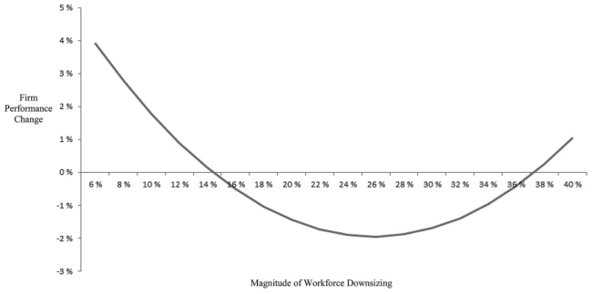

NOTE: figure/graphic rendered as an image from the PDF; its content is not machine-readable text. Caption (if any) follows as the next block.

providing support for Hypothesis 1 on a U-shaped relationship between the magnitude of workforce downsizing and performance. This is consistent with our prediction that firms that downsize on a small scale and those that downsize their workforce on a large scale both exhibit the highest performance improvements. Intermediate downsizers exhibit the least positive performance. In order to visualize the nature of the relationship, see Figure 1.

Model 4 provides a test for Hypothesis 2 in which we predicted that proactive timing of workforce downsizing would lead to a more pronounced U-shaped relationship between magnitude of workforce downsizing and firm performance. The coefficient of the interaction term with the squared term of magnitude of workforce downsizing is positive and statistically significant (p < 0.001). The coefficient of the magnitude of workforce downsizing variable is also larger than in Model 3, indicating a more pronounced slope. Hypothesis 2 thus finds support. Figure 2 illustrates the nature of the effect of timing on the relationship between the magnitude of workforce downsizing and post-downsizing performance changes.

#### **Robustness Tests**

We also performed further tests to establish the robustness of our results. First, we used different base years and time windows to assess post-downsizing performance. We calculated the increase in ROA in the three year post-downsizing period relative to the year in which the downsizing occurred instead of using the year prior to the downsizing as base year. Following a procedure used in prior research (e.g., Perry and Shivdasani, 2005), we also measured the change in ROA between the year of downsizing and the subsequent two years. The results of these analyses were consistent with those reported above in our regression results.

Figure 1. Relationship between magnitude of workforce downsizing and change in firm performance

Workforce Downsizing and Firm Performance 1325

© 2013 John Wiley & Sons Ltd and Society for the Advancement of Management Studies

Page 16

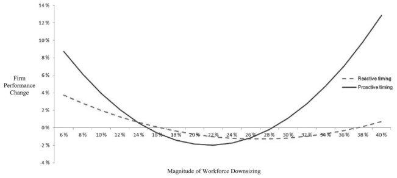

NOTE: figure/graphic rendered as an image from the PDF; its content is not machine-readable text. Caption (if any) follows as the next block.

Second, when using return on invested capital as an alternative measure of the performance implications of workforce downsizing,<sup>[5]</sup> we again find support for a U-shaped relationship between the magnitude of workforce downsizing and postdownsizing performance (p < 0.05). Also, the proactiveness of downsizing is found to significantly enhance the effect of workforce downsizing on post-downsizing firm performance in terms of return on invested capital (p < 0.05).

#### **DISCUSSION AND IMPLICATIONS**

This study focuses on the relationship between the magnitude of workforce downsizing and firm performance. Applying an organizational routine perspective, we posit and find that the relationship between the magnitude of workforce downsizing and firm performance improvements is non-linear (U-shaped). Small-scale downsizing is argued to lead to more significant performance improvements when compared with medium-scale downsizing since small-scale downsizing eliminates operational inefficiencies without disrupting existing routines. Additionally, survivor effects are likely to be less severe in small-scale downsizing when compared to medium-scale downsizing.

Figure 2. Moderating effect of proactiveness (timing) on the relationship between magnitude of workforce downsizing and change in firm performance

M. Brauer and T. Laamanen 1326

© 2013 John Wiley & Sons Ltd and Society for the Advancement of Management Studies

Page 17

We also find that proactive timing of workforce downsizing constitutes a relevant process contingency which, consistent with prior research (Love and Nohria, 2005; Markides, 1995; Ravenscraft and Scherer, 1987), leads to more positive post-downsizing performance improvements but is also found to make the U-shaped relationship between magnitude of workforce downsizing and firm performance improvements *more* pronounced.

#### **Theoretical Implications**

We contribute to an improved understanding of the performance implications of workforce downsizing in several ways. First, we extend prior research on workforce downsizing by challenging the general notion that the relationship between magnitude of workforce downsizing and firm performance improvements is in fact linear, applying an organizational routine perspective. Second, our results draw attention to the fact that the timing of downsizing matters. In line with recent contributions in this area (Datta et al., 2010), we concur that the identification and analysis of critical, internal, and external conditions is an important task for improving our understanding of the effectiveness of downsizing. Third and finally, we also contribute to the research on workforce downsizing by demonstrating the existence of viable, alternative theoretical perspectives to examine the phenomenon. Though we are unable to directly observe the processes of routine re-creation as part of our study design, the empirical results support the potential usefulness of the organizational routine perspective for predicting the outcomes of workforce downsizing. Specifically, complementing motivation theory, which has been central to survivor research, with an organizational routine perspective seems to provide for a more comprehensive explanation of the mixed findings in past downsizing studies.

Our research is positioned in the intersection of the literatures on organizational routines and workforce downsizing. Despite the tendency to define routines as ‘effortful accomplishments’ (Pentland and Rueter, 1994, p. 488) and the recognition of the importance of mindfulness (e.g., Jordan et al., 2009; Levinthal and Rerup, 2006; Weick and Sutcliffe, 2006), prior research on routines has been relatively silent on the role of the cognitive effort in routine emergence. While in psychology and learning literatures, there is an extensive body of work on the effects of individual level cognitive effort of an individual’s attention, learning, and performance (e.g., Bertsch et al., 2007; Piolat et al., 2005), in organization research the role and effects of cognitive effort have so far received limited attention (O’Reilly and Chatman, 1994; Todd and Benbasat, 1999).

While earlier research has found that changes in routines can be driven by changes in the external environment (e.g., Cohen et al., 1996), continuous internal adaptation (Feldman, 2000), or imperfect internal replication (Becker et al., 2006), we argue that cognitive effort and motivation are needed for changing routines following major internal disruptions. When approaching the change of routines from the perspective of cognitive effort, we posit that there is a major difference in whether routines are simply adapted through local search with lower cognitive effort (e.g., Argote and Greve, 2007; Cyert and March, 1963) or whether a more significant cognitive effort is undertaken.

We argue that the amount of cognitive effort spent on routine creation is an important determinant of routine re-creation that has been to some extent missing from prior

Workforce Downsizing and Firm Performance 1327

© 2013 John Wiley & Sons Ltd and Society for the Advancement of Management Studies

Page 18

research. Based on our empirical analysis we suggest that internal pressure due to the inability to salvage the existing routines combined with the availability of time may provide a good context for creating new organizational routines.

#### **Practical Implications**

Our findings also point to some implications for managers. Previous research on the performance of downsizing and non-downsizing companies largely suggests that managers should first consider viable alternatives (e.g., short-time, leave with partial pay and benefits intact, part-time work, early retirements, unpaid extra working time) before resorting to workforce downsizing. While our results indicate that workforce downsizing on a broader scale may indeed help a company to restore its financial performance, managers should not misread our results as a call for blindly resorting to downsizing activity.

In keeping with Cascio (2002), we believe that managers should carefully weigh the different alternatives that are at hand. Little knowledge, however, has been generated on how workforce downsizing should be managed if none of these alternatives are feasible. This study addresses this shortcoming by generating some tentative advice on how to implement workforce downsizing to improve firm performance. Findings indicate that the magnitude and proactiveness of workforce downsizing are important parameters in the implementation.

#### **Limitations and Avenues for Future Research**

Our paper opens up a number of potential directions for future research. First, while our theorizing highlights the importance of considering the processes of routine re-creation, our current data does not allow for a direct measurement of the extent of routine disruption and employees’ cognitive efforts in routine reformation. Micro-level studies on the internal dynamics of downsizing would thus constitute a valuable complement for our study in order to better understand the deeper level cognitive and psychological dynamics underlying downsizing. In particular, studies which employ longitudinal and repeated cross-sectional survey designs would be needed to more accurately capture the degree of routine disruption associated with different levels of downsizing and to assess the cognitive efforts and psychological states of employees following downsizing. Furthermore, our data did not allow us to discern whether downsizing has disparate disruptive effects on routines at different organizational levels. In-depth multiple case study analyses which examine the effects of downsizing on routines of different order (Winter, 2000) and at different organizational levels thus bear great potential to advance our understanding of the relationship between workforce downsizing and firm performance. Moreover, building on the work by DeRue et al. (2008), simulation studies could also be used to examine how individuals’ cognitive effort changes when the magnitude of workforce downsizing exceeds the threshold beyond which the team can no longer salvage its routine for performing a given task.

Second, as evidenced by our results, process issues such as the timing of the downsizing seem to have an important influence on downsizing performance. Greater attention to

M. Brauer and T. Laamanen 1328

© 2013 John Wiley & Sons Ltd and Society for the Advancement of Management Studies

Page 19

the characteristics of the downsizing process would thus seem to be needed. When doing so, however, it is important to note that the use of archival data such as change in market capitalization as a proxy for a firm’s proactiveness has its limitations. Further studies using primary survey data would thus be of value to advance our understanding about the influence of fine-grained process issues, such as the nature of the routine disruption, and in order to assess the validity of commonly used secondary firm-level proxies.

Third, our empirical analysis was based on a sample of large, publicly-listed firms in Europe during a particular time-span (1996–2006). Thus, our findings may be region, company type, and time period specific. Therefore the generalizability of our findings, for example, with regard to small- and medium-sized companies should be explored in future studies. Given that the social context in small and medium sized companies might be very different due to firm size, alternative outcomes are feasible. In the same vein, the study of downsizing in family firms might be a worthwhile avenue for future research as these types of firms have been claimed to provide a special social context which may amplify negative affect and thus lead to different implications.

Finally, even though we did not find any differences in our sample regarding the downsizing performance link across different industries, one could argue that employees in some industries are more accustomed to workforce downsizing than in others. For example, in industries that have not experienced much downsizing, a reduction in workforce might trigger higher levels of anxiety and insecurity than in other industries where downsizing has been more commonplace and employees have been conditioned to it.<sup>[6]</sup> Thus, another future research opportunity could also be to examine the generalizability of our findings in the context of different industries that differ from each other in terms of how accustomed the employees are to downsizing events. Similarly, the European context may be argued to differ from the US context in terms of the frequency and extent of downsizing, influencing the perception of the phenomenon of downsizing among both employees and investors. It might thus be worthwhile in future studies to also examine the effects of the different institutional contexts on the downsizing– performance link. In addition to the different cultural dynamics associated with downsizing, regulatory differences are also likely to affect whether and when firms choose to downsize.

In conclusion, since downsizing has in recent years become a common practice for management teams in large firms to react to different kinds of threats and setbacks, we call for a more fine-grained research on the contextual determinants and longer-term consequences of downsizing. This is an area where scientific research has potentially a lot to give for management teams operating under high external short-term pressures to satisfy the capital markets.

#### **NOTES**

[1] It should be noted, however, that even for these studies the empirical evidence is not always straight-

forward and consistent. For instance, Kang and Shivdasani (1997) only find improvements in operating performance in the third year following downsizing. Palmon and Sun (1997) find that performance improvements in ROA, return on equity (ROE), or sales can only be detected when using *t* −2 as the base year and *t* + 2 as the year for comparison. Espahbodi et al. (2000) found that downsizing firms exhibited higher ROE only three to four years after downsizing, and no significant improvements in

Workforce Downsizing and Firm Performance 1329

© 2013 John Wiley & Sons Ltd and Society for the Advancement of Management Studies

Page 20

ROA. In contrast, Chen et al. (2001) found that relative to non-downsizing firms, downsizing firms had greater improvements in both ROA and operating margins/sales in the 3-year post-downsizing period. Further, Yu and Park (2006) found that only firms that had no losses in the years prior to downsizing exhibited positive and significant improvements in ROA. [2] According to Brockner et al. (1994), severe downsizing referred to reductions greater than 25 per cent

and up to 70 per cent. [3] Cognitive effort has been conceptualized as a limited capacity resource that affects the speed of

information processing (Humphreys and Revelle, 1984; Kahneman, 1973). [4] Creativity research showed that time pressure has a particularly negative impact on creativity when a

creative task is not formulated, or not within an employee’s traditional work role (i.e., modifying procedures) (Unsworth, 2001; Unsworth and Clegg, 2000). [5] We did not use ROE, as some prior studies did, due to the fact that the ROE measure is distorted by

a company’s capital structure (i.e., the mix of debt and equity). [6] We would like to thank one of our anonymous reviewers for this insight.

#### **REFERENCES**

Adler, P. S., Goldoftas, B. and Levine, D. I. (1999). ‘Flexibility versus efficiency? A case study of model

changeovers in the Toyota production system’. *Organization Science*, **10**, 43–68. Ahmadjian, C. L. and Robinson, P. (2001). ‘Safety in numbers: downsizing and the deinstitutionalization of

permanent employment in Japan’. *Administrative Science Quarterly*, **46**, 622–54. Aiken, L. S. and West, S. G. (1991). *Multiple Regression: Testing and Interpreting Interactions*. Newbury Park, CA:

Sage. Aime, F., Johnson, S., Ridge, J. W. and Hill, A. D. (2010). ‘The routine may be stable but the advantage is

not: competitive implications of key employee mobility’. *Strategic Management Journal*, **31**, 75–87. Argote, L. and Greve, H. R. (2007). ‘A behavioral theory of the firm – 40 years and counting: introduction

and impact’. *Organization Science*, **18**, 337–49. Armstrong-Stassen, M. (1994). ‘Coping with transition: a study of layoff survivors’. *Journal of Organizational*

*Behavior*, **15**, 597–621. Ashforth, B. E. and Fried, Y. (1988). ‘The mindlessness of organizational behaviors’. *Human Relations*, **41**,

305–29. Baumol, W. J., Blinder, A. and Wolff, E. N. (2003). *Downsizing in America: Reality, Causes, and Consequences*. New

York: Russell Sage Foundation. Becker, M. C. (2004). ‘Organizational routines: a review of the literature’. *Industrial and Corporate Change*, **13**,

643–77. Becker, M. C., Knudsen, T. and March, J. G. (2006). ‘Schumpeter, winter, and the sources of novelty’.

*Industrial and Corporate Change*, **15**, 353–71. Bertsch, S., Pesta, B. and Wiscott, R. (2007). ‘The generation effect: a meta-analytic review’. *Memory &*

*Cognition*, **35**, 201–10. Brauer, M. and Wiersema, M. (2012). ‘Industry divestiture waves: how a firm’s position influences investor

returns’. *Academy of Management Journal*, **55**, 1472–92. Brockner, J., Konovsky, M., Cooperschneider, R., Folger, R., Martin, C. and Bies, R. J. (1994). ‘Interactive

effects of procedural justice and outcome negativity on victims and survivors of job loss’. *Academy of Management Journal*, **37**, 397–409. Brockner, J., Siegel, P. A., Daly, J. P., Tyler, T. and Martin, C. (1997). ‘When trust matters: the moderating

effect of outcome favorability’. *Administrative Science Quarterly*, **42**, 558–83. Bromiley, P. (1991). ‘Testing a causal model of corporate risk-taking and performance’. *Academy of Manage-*

*ment Journal*, **34**, 37–59. Bruderer, E. and Singh, J. V. (1996). ‘Organizational evolution, learning, and selection: a genetic-algorithm-

based model’. *Academy of Management Journal*, **39**, 1322–49. Bruton, G. D., Keels, J. K. and Shook, C. L. (1996). ‘Downsizing the firm: answering the strategic questions’.

*Academy of Management Executive*, **10**, 38–45. Buchholtz, A. K., Lubatkin, M. and O’Neill, H. M. (1999). ‘Seller responsiveness to the need to divest’.

*Journal of Management*, **25**, 633–52. Cameron, K. S. (1994). ‘Strategies for successful organizational downsizing’. *Human Resource Management*, **33**,

189–211. Cameron, K. S., Kim, M. U. and Whetten, D. A. (1987a). ‘Organizational effects of decline and turbulence’.

*Administrative Science Quarterly*, **32**, 222–40.

M. Brauer and T. Laamanen 1330

© 2013 John Wiley & Sons Ltd and Society for the Advancement of Management Studies

Page 21

Cameron, K. S., Whetten, D. A. and Kim, M. U. (1987b). ‘Organizational dysfunctions of decline’. *Academy*

*of Management Journal*, **30**, 126–38. Cameron, K. S., Freeman, S. J. and Mishra, A. K. (1991). ‘Best practices in white-collar downsizing:

managing contradictions’. *Executive*, **5**, 57–73. Cascio, W. F. (1993). ‘Downsizing: What do we know? What have we learned?’. *Academy of Management*

*Executive*, **7**, 95–104. Cascio, W. F. (1997). ‘Learning from outcomes: financial experiences of 311 firms that have downsized’. In

Gowing, M. K., Kraft, J. D. and Quick, J. C. (Eds), *The New Organizational Reality: Downsizing, Restructuring and Revitalization*. Washington DC: American Psychological Association, 55–70. Cascio, W. F. (2002). *Responsible Restructuring: Creative and Profitable Alternatives to Layoffs*. San Francisco, CA:

Berret-Koehler Publishers. Cascio, W. F., Young, C. E. and Morris, J. R. (1997). ‘Financial consequences of employment-change

decisions in major US corporations’. *Academy of Management Journal*, **40**, 1175–89. Chadwick, C., Hunter, L. W. and Walston, S. L. (2004). ‘Effects of downsizing practices on the performance

of hospitals’. *Strategic Management Journal*, **25**, 405–27. Chen, P., Mehrotra, V., Sivakumar, K. and Yu, W. W. (2001). ‘Layoffs, shareholders’ wealth, and corporate

performance’. *Journal of Empirical Finance*, **8**, 171–99. Cohen, A., Burkhardt, R., Dosi, G., Egidi, M., Marengo, L., Warglien, M. and Winter, S. (1996). ‘Routines

and other recurring action patterns of organizations: contemporary research issues’. *Industrial and Corporate Change*, **5**, 653–98. Cohen, J., Cohen, P., West, S. G. and Aiken, L. S. (2003). *Applied Multiple Regression/Correlation Analysis for the*

*Behavioral Sciences*. Mahwah, NJ: Erlbaum. Cohen, M. D. and Bacdayan, P. (1994). ‘Organizational routines are stored as procedural memory –

evidence from a laboratory study’. *Organization Science*, **5**, 554–68. Cyert, R. M. and March, J. G. (1963). *A Behavioral Theory of the Firm*. Englewood Cliffs, NJ: Prentice Hall. Datta, D. K., Guthrie, J. P., Basuil, D. and Pandey, A. (2010). ‘Causes and effects of employee downsizing:

a review and synthesis’. *Journal of Management*, **36**, 281–348. Datta, D. K., Basuil, D. and Radeva, E. A. (2012). ‘Employee downsizing and organizational performance:

what do we know?’. In Cooper, C. L., Pandey, A. and Quick, J. C. (Eds), *Downsizing: Is Less Still More? Downsizing in a Global Retrenchment and Beyond*. Cambridge: Cambridge University Press, 199–227. DeMeuse, K. P., Van der Heiden, P. A. and Bergmann, T. J. (1994). ‘Announced layoffs: their effect on

corporate financial performance’. *Human Resource Management*, **33**, 509–30. DeMeuse, K. P., Bergmann, T. J. and Van der Heiden, P. A. (1997). ‘Corporate downsizing – separating

myth from fact’. *Journal of Management Inquiry*, **6**, 168–76. DeMeuse, K. P., Bergmann, T. J., Van der Heiden, P. A. and Roraff, C. E. (2004). ‘New evidence regarding

organizational downsizing and a firm’s financial performance: a long-term analysis’. *Journal of Managerial Issues*, **16**, 155–77. Derue, D. S., Hollenbeck, J. R., Johnson, M. D., Ilgen, D. R. and Jundt, D. K. (2008). ‘How different team

downsizing approaches influence team-level adaptation and performance’. *Academy of Management Journal*, **51**, 182–96. Dewitt, R. L. (1998). ‘Firm, industry, and strategy influences on choice of downsizing approach’. *Strategic*

*Management Journal*, **19**, 59–79. Dranikoff, L., Koller, T. and Schneider, A. (2002). ‘Selling early and selling often’. *Mergers & Acquisitions: The*

*Dealmaker’s Journal*, **37**, 33–37. Edmondson, A. C., Bohmer, R. M. and Pisano, G. P. (2001). ‘Disrupted routines: team learning and new

technology implementation in hospitals’. *Administrative Science Quarterly*, **46**, 685–716. Eisenhardt, K. M. and Martin, J. A. (2000). ‘Dynamic capabilities: what are they?’. *Strategic Management*

*Journal*, **21**, 1105–21. Espahbodi, R., John, T. A. and Vasudevan, G. (2000). ‘The effects of downsizing on operating performance’.

*Review of Quantitative Finance and Accounting*, **15**, 107–26. Feldman, M. S. (2000). ‘Organizational routines as a source of continuous change’. *Organization Science*, **11**,

611–29. Feldman, M. S. (2003). ‘A performative perspective on stability and change in organizational routines’.

*Industrial and Corporate Change*, **12**, 727–52. Feldman, M. S. and Pentland, B. T. (2003). ‘Reconceptualizing organizational routines as a source of

flexibility and change’. *Administrative Science Quarterly*, **48**, 94–118. Felin, T., Foss, N. J., Heimeriks, K. H. and Madsen, T. L. (2012). ‘Microfoundations of routines and

capabilities: individuals, processes, and structure’. *Journal of Management Studies*, **49**, 1351–74.

Workforce Downsizing and Firm Performance 1331

© 2013 John Wiley & Sons Ltd and Society for the Advancement of Management Studies

Page 22

Freeman, S. J. (1999). ‘The gestalt of organizational downsizing: downsizing strategies as packages of

change’. *Human Relations*, **52**, 1505–42. Freeman, S. J. and Cameron, K. S. (1993). ‘Organizational downsizing – a convergence and reorientation

framework’. *Organization Science*, **4**, 10–29. Gersick, C. (1991). ‘Revolutionary change theories: a multilevel exploration of the punctuated equilibrium

paradigm’. *Academy of Management Review*, **16**, 10–36. Gilson, C., Hurd, F. and Wagar, T. H. (2004). ‘Creating a concession climate: the case of serial downsizers’.

*International Journal of Human Resource Management*, **15**, 1056–68. Ginsberg, A. and Baum, J. A. (1994). ‘Evolutionary processes and patterns of core business change’. In

Baum, J. A. and Singh, H. (Eds), *Evolutionary Dynamics of Organizations*. New York: Oxford University Press, 127–51. Greene, W. H. (2000). *Econometric Analysis*, 4th edition. Upper Saddle River, NJ: Prentice Hall. Greve, H. R. (1998). ‘Performance, aspirations, and risky organizational change’. *Administrative Science*

*Quarterly*, **43**, 58–86. Guthrie, J. P. and Datta, D. K. (2008). ‘Dumb and dumber: the impact of downsizing on firm performance

as moderated by industry conditions’. *Organization Science*, **19**, 108–23. Hallock, K. F., Strain, M. and Webber, D. (2012). ‘Job loss and effects on firms and workers’. In Cooper, C.

L., Pandey, A. and Quick, J. C. (Eds), *Downsizing: Is Less Still More? Downsizing in a Global Retrenchment and Beyond*. Cambridge: Cambridge University Press, 3–51. Hausman, J., Hall, B. H. and Griliches, Z. (1984). ‘Econometric models for count data with an application

to the patents–R&D relationship’. *Econometrica*, **52**, 909–38. Hodgkinson, G. P. (2003). ‘The interface of cognitive and industrial, work and organizational psychology’.

*Journal of Occupational and Organizational Psychology*, **76**, 1–25. Humphreys, M. S. and Revelle, W. (1984). ‘Personality, motivation, and performance: a theory of the

relationship between individual differences and information processing’. *Psychological Review*, **91**, 153– 84. Jensen, M. C. (1993). ‘The modern industrial revolution, exit, and the failure of internal control systems’.

*Journal of Finance*, **48**, 831–75. Jordan, S., Messner, M. and Becker, A. (2009). ‘Reflection and mindfulness in organizations: rationales and

possibilities for integration’. *Management Learning*, **40**, 465–73. Kahneman, D. (1973). *Attention and Effort*. Englewood Cliffs, NJ: Prentice-Hall. Kang, J. K. and Shivdasani, A. (1997). ‘Corporate restructuring during performance declines in Japan’.

*Journal of Financial Economics*, **46**, 29–65. Kozlowski, S. W. J., Chao, G. T., Smith, E. M. and Hedlund, J. (1993). ‘Organizational downsizing:

strategies, interventions, and research implications’. *International Review of Industrial Organizational Psychology*, **8**, 263–332. Lazaric, N. (2011). ‘Organizational routines and cognition: an introduction to empirical and analytical

contributions’. *Journal of Institutional Economics*, **7**, 147–56. Levinthal, D. and Rerup, C. (2006). ‘Crossing an apparent chasm: bridging mindful and less-mindful

perspectives on organizational learning’. *Organization Science*, **17**, 502–13. Love, E. G. and Nohria, N. (2005). ‘Reducing slack: the performance consequences of downsizing by large

industrial firms, 1977–93’. *Strategic Management Journal*, **26**, 1087–108. Markides, C. C. (1995). ‘Diversification, restructuring and economic-performance’. *Strategic Management*

*Journal*, **16**, 101–18. Neter, J., Kutner, M. and Wasserman, W. (1996). *Applied Linear Statistical Models*. New York: McGraw-Hill/

Irwin. O’Reilly, C. A. and Chatman, J. A. (1994). ‘Working smarter and harder – a longitudinal-study of

managerial success’. *Administrative Science Quarterly*, **39**, 603–27. Orlikowski, W. J. (2002). ‘Knowing in practice: enacting a collective capability in distributed organizing’.

*Organization Science*, **13**, 249–73. Palmon, O. and Sun, H. L. (1997). ‘Layoff announcements: stock market impact and financial performance’.

*Financial Management*, **26**, 54–68. Pentland, B. T. (1995). ‘Grammatical models of organizational processes’. *Organization Science*, **6**, 541–

56. Pentland, B. T. and Feldman, M. S. (2005). ‘Organizational routines as a unit of analysis’. *Industrial and*

*Corporate Change*, **14**, 793–815. Pentland, B. T. and Rueter, H. H. (1994). ‘Organizational routines as grammars of action’. *Administrative*

*Science Quarterly*, **39**, 484–510.

M. Brauer and T. Laamanen 1332

© 2013 John Wiley & Sons Ltd and Society for the Advancement of Management Studies

Page 23

Perry, T. and Shivdasani, A. (2005). ‘Do boards affect performance? Evidence from corporate restructuring’.

*Journal of Business*, **78**, 1403–31. Piolat, A., Olive, T. and Kellogg, R. T. (2005). ‘Cognitive effort during note taking’. *Applied Cognitive*

*Psychology*, **19**, 291–312. Ravenscraft, D. J. and Scherer, F. M. (1987). *Mergers, Sell-Offs and Economic Efficiency*. New York: Brookings

Institute. Salvato, C. (2009). ‘Capabilities unveiled: the role of ordinary activities in the evolution of product devel-

opment processes’. *Organization Science*, **20**, 384–409. Staw, B. M., Sanderlands, L. and Dutton, J. (1981). ‘Threat rigidity effects in organizational behaviour: a

multi-level analysis’. *Administrative Science Quarterly*, **26**, 147–60. Suarez-Gonzalez, I. (2001). ‘Downsizing strategy: does it really improve organizational performance?’.

*International Journal of Management*, **18**, 301–07. Todd, P. and Benbasat, I. (1999). ‘Evaluating the impact of DSS, cognitive effort, and incentives on strategy

selection’. *Information Systems Research*, **10**, 356–74. Tripsas, M. (2009). ‘Technology, identity, and inertia through the lens of “the digital photography

company” ’. *Organization Science*, **20**, 441–60. Ulrich, W. (2011). ‘Emergence and functionality of organizational routines: an individualistic approach’.

*Journal of Institutional Economics*, **7**, 157–74. Unsworth, K. (2001). ‘Unpacking creativity’. *Academy of Management Review*, **26**, 289–97. Unsworth, K. L. and Clegg, C. (2000). ‘Employee innovation: report to participating companies’. Internal

Report, University of Sheffield. Vicente-Lorente, J. D. and Suarez-Gonzalez, I. (2007). ‘Ownership traits and downsizing behaviour:

evidence for the largest Spanish firms, 1990–1998’. *Organization Studies*, **28**, 1613–38. Wagar, T. H. (1998). ‘Exploring the consequences of workforce reductions’. *Canadian Journal of Administrative*

*Sciences*, **15**, 300–09. Wayhan, V. B. and Werner, S. (2000). ‘The impact of workforce reductions on financial performance: a

longitudinal perspective’. *Journal of Management*, **26**, 341–63. Weick, K. E. and Sutcliffe, K. A. (2006). ‘Mindfulness and the quality of organizational attention’. *Organi-*

*zation Science*, **17**, 514–24. Winter, S. G. (2000). ‘The satisficing principle in capability learning’. *Strategic Management Journal*, **21**,

981–96. Yu, G. C. and Park, J. S. (2006). ‘The effect of downsizing on the financial performance and employee

productivity of Korean firms’. *International Journal of Manpower*, **27**, 230–50. Zellmer-Bruhn, M. E. (2003). ‘Interruptive events and team knowledge acquisition’. *Management Science*, **49**,

514–28.

Workforce Downsizing and Firm Performance 1333

© 2013 John Wiley & Sons Ltd and Society for the Advancement of Management Studies